# Propensity score weighted analysis of college student mental health in early COVID-19

Companion vignette for Shearer et al., *PLOS Mental Health* (under revision)

## Overview

This vignette documents the analysis behind the paper and reproduces every number reported in its tables and supplementary materials. It is organised in the same order as the analysis itself.

1. The analytic sample and the subgroups.
2. The treatment contrasts and how each is coded.
3. The causal estimand and identifying assumptions.
4. Propensity score estimation with XGBoost and inverse probability weighting.
5. Weighting diagnostics (Supplementary Table S2, Fig S1, S1 Data).
6. Treatment effect estimates (Tables 3 to 7).
7. The Benjamini and Hochberg adjustment.

The model-fitting step (step 4) requires the `xgboost` R package and is run by `R/causal_ipw.R`, which writes the files in `output/`. This vignette reads those saved outputs, so it renders without refitting the models, and it recomputes from the raw data everything that does not depend on the fitted propensity scores.

To reproduce the full analysis from scratch:

```bash
# from the student-mh-causal/ folder
Rscript R/causal_ipw.R          # fits all 46 models, writes output/
Rscript -e 'rmarkdown::render("vignette/vignette.Rmd")'
```

## 1. Data and analytic sample

The data come from an online survey of students at a large public university in the Mid-Atlantic United States, administered between April 9 and June 3, 2020. The analytic sample contains **295 students**, each with complete information on all study variables except age, which is missing for 80 students.

The outcome, `mh_scale`, is the mean of the 21 items of the Depression Anxiety Stress Scales (DASS-21). It ranges from 0 to 3, and higher values indicate greater psychological distress.

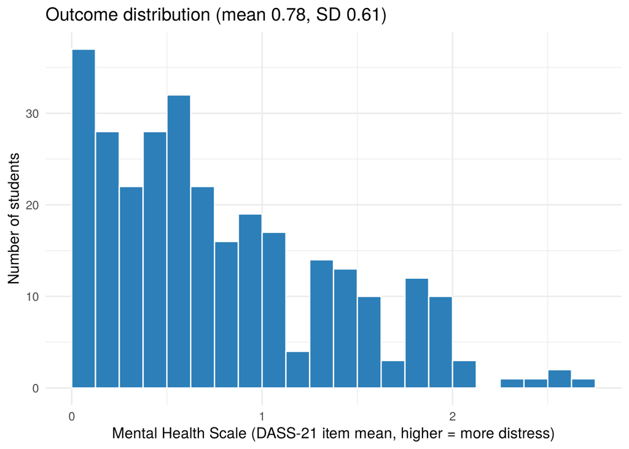

```r
ggplot(dat, aes(mh_scale)) +
  geom_histogram(binwidth = 0.125, boundary = 0, fill = "#2C7FB8", colour = "white") +
  labs(x = "Mental Health Scale (DASS-21 item mean, higher = more distress)",
       y = "Number of students",
       title = sprintf("Outcome distribution (mean %.2f, SD %.2f)",
                       mean(dat$mh_scale), sd(dat$mh_scale))) +
  theme_minimal(base_size = 12)
```

### Subgroups

Analyses were run in the full sample and separately within subgroups defined by PTSD symptom severity, gender identity, race, and age. Students identifying as gender minorities (n = 14) were too few for a separate gender stratum, and age-stratified analyses use the 215 students with recorded age.

```r
sub_n <- tibble::tribble(
  ~Stratification, ~Subgroup, ~n,
  "None",        "Full sample",                         nrow(dat),
  "PTSD",        "High symptom severity (PCL-5 ≥ 33)", sum(dat$ptsd_score >= 33),
  "PTSD",        "Low symptom severity (PCL-5 < 33)",   sum(dat$ptsd_score < 33),
  "Gender",      "Cisgender women",                     sum(dat$gender == 0),
  "Gender",      "Cisgender men",                       sum(dat$gender == 1),
  "Race",        "White",                               sum(dat$race == 0),
  "Race",        "Asian/Asian-American",                sum(dat$race == 2),
  "Race",        "Other racial identities",             sum(dat$race == 1),
  "Age",         "18–20",                          sum(dat$age <= 20, na.rm = TRUE),
  "Age",         "21–24",                          sum(dat$age %in% 21:24),
  "Age",         "25 and older",                        sum(dat$age >= 25, na.rm = TRUE)
)
kable(sub_n, caption = "Subgroup sample sizes") %>%
  kable_styling(full_width = FALSE, bootstrap_options = c("striped", "condensed")) %>%
  collapse_rows(columns = 1, valign = "top")
```

Subgroup sample sizes

| Stratification | Subgroup | n |
| --- | --- | --- |
| None | Full sample | 295 |
| PTSD | High symptom severity (PCL-5 ≥ 33) | 89 |
|  | Low symptom severity (PCL-5 < 33) | 206 |
| Gender | Cisgender women | 227 |
|  | Cisgender men | 54 |
| Race | White | 127 |
|  | Asian/Asian-American | 54 |
|  | Other racial identities | 114 |
| Age | 18–20 | 84 |
|  | 21–24 | 92 |
|  | 25 and older | 39 |

## 2. Treatment definitions

Every exposure is dichotomized so that the average treatment effect (ATE) compares two well-defined groups of students. The table gives the exact definition of the group coded 1, the reason for the cutoff, and the number of treated students in the full sample, computed directly from the data.

```r
trt_tab <- tibble::tribble(
  ~Treatment, ~`Coded 1 if`, ~Justification, ~`Treated (full sample)`,
  "GPA ≤ 3.0", "Self-reported cumulative GPA at or below 3.0",
    "B average; standard benchmark for good academic standing", sum(dat$gpa_thresh3_0 == 1),
  "PTSD score ≥ 33", "PCL-5 total of 33 or higher (range 0–80)",
    "Recommended threshold for probable PTSD (Bovin et al., 2016); not a diagnosis", sum(dat$ptsd_score >= 33),
  "COVID-19 isolation > 7", "Isolation item above 7 (0 = strongly disagree, 10 = strongly agree)",
    "Clear agreement on a scale with neutral point 5; just above the sample median of 7", sum(dat$covid_iso > 7),
  "Educational helpers ≥ 3", "Three or more network members giving intense educational help",
    "Above the median of 2 intense educational helpers", sum(dat$edu.i_count >= 3),
  "Max. emotional help ≥ 9", "Highest emotional-help rating of any network member is 9 or 10",
    "At least one source of near-maximal emotional support", sum(dat$max.emohelp >= 9),
  "Academic perseverance > median", sprintf("Academic perseverance above %.1f (1–6 scale)", median(dat$acpers)),
    "Full-sample median split", sum(dat$acpers > median(dat$acpers)),
  "Not a cisgender woman", "Gender identity other than cisgender woman",
    "Used only within the PTSD strata", sum(dat$gender != 0),
  "Trauma score > median", sprintf("Trauma item sum above %d", as.integer(median(dat$trauma_sum))),
    "Full-sample median split. Higher scores mean FEWER reported traumatic experiences", sum(dat$trauma_sum > median(dat$trauma_sum))
)
kable(trt_tab, caption = "Treatment contrasts (group coded 0 is everyone else in the analytic sample)") %>%
  kable_styling(bootstrap_options = c("striped", "condensed"), font_size = 13)
```

Treatment contrasts (group coded 0 is everyone else in the analytic sample)

| Treatment | Coded 1 if | Justification | Treated (full sample) |
| --- | --- | --- | --- |
| GPA ≤ 3.0 | Self-reported cumulative GPA at or below 3.0 | B average; standard benchmark for good academic standing | 69 |
| PTSD score ≥ 33 | PCL-5 total of 33 or higher (range 0–80) | Recommended threshold for probable PTSD (Bovin et al., 2016); not a diagnosis | 89 |
| COVID-19 isolation > 7 | Isolation item above 7 (0 = strongly disagree, 10 = strongly agree) | Clear agreement on a scale with neutral point 5; just above the sample median of 7 | 137 |
| Educational helpers ≥ 3 | Three or more network members giving intense educational help | Above the median of 2 intense educational helpers | 109 |
| Max. emotional help ≥ 9 | Highest emotional-help rating of any network member is 9 or 10 | At least one source of near-maximal emotional support | 221 |
| Academic perseverance > median | Academic perseverance above 4.5 (1–6 scale) | Full-sample median split | 140 |
| Not a cisgender woman | Gender identity other than cisgender woman | Used only within the PTSD strata | 68 |
| Trauma score > median | Trauma item sum above 10 | Full-sample median split. Higher scores mean FEWER reported traumatic experiences | 118 |

The trauma score is scored in the reverse of what its name suggests. Its correlation with the PCL-5 score is -0.51 and with the outcome -0.35, so the trauma indicator identifies students reporting comparatively *less* trauma exposure.

Which treatments are examined in which stratum:

```r
res %>%
  distinct(Group, Treatment) %>%
  mutate(x = "✓") %>%
  pivot_wider(names_from = Treatment, values_from = x, values_fill = "") %>%
  kable(caption = "Analysis plan: 46 treatment effects in 11 analytic samples") %>%
  kable_styling(bootstrap_options = c("condensed"), font_size = 12)
```

Analysis plan: 46 treatment effects in 11 analytic samples

| Group | GPA ≤ 3.0 | PTSD score ≥ 33 | COVID-19 isolation > 7 | Educational helpers ≥ 3 | Academic perseverance > median | Not a cisgender woman | Trauma score > median | Max. emotional help ≥ 9 |
| --- | --- | --- | --- | --- | --- | --- | --- | --- |
| Full sample | ✓ | ✓ | ✓ | ✓ |  |  |  |  |
| High PTSD symptom severity | ✓ |  | ✓ |  | ✓ | ✓ | ✓ |  |
| Low PTSD symptom severity | ✓ |  | ✓ |  | ✓ | ✓ | ✓ |  |
| Cisgender women | ✓ | ✓ | ✓ | ✓ |  |  |  |  |
| Cisgender men | ✓ | ✓ | ✓ | ✓ |  |  |  |  |
| White students | ✓ | ✓ | ✓ | ✓ |  |  |  |  |
| Asian/Asian-American students | ✓ | ✓ | ✓ | ✓ |  |  |  |  |
| Students of other racial identities | ✓ | ✓ | ✓ | ✓ |  |  |  |  |
| Ages 18–20 | ✓ | ✓ | ✓ |  |  |  |  | ✓ |
| Ages 21–24 | ✓ | ✓ | ✓ |  |  |  |  | ✓ |
| Ages 25+ | ✓ | ✓ | ✓ |  |  |  |  | ✓ |

## 3. Causal framework

Each student $i$ has two potential outcomes, $Y_i(1)$ under treatment and $Y_i(0)$ without it, and the estimand is the average treatment effect

$$\text{ATE} = \mathbb{E}\left[Y(1) -
Y(0)\right].$$

The ATE is identified from observational data under three assumptions.

- **Consistency.** The observed outcome equals the potential outcome under the treatment received.
- **Conditional exchangeability.** Given the measured covariates, treatment assignment is independent of the potential outcomes, so there is no unmeasured confounding.
- **Positivity.** Every student has a probability strictly between 0 and 1 of being in either group.

The assumed causal structure is shown below with GPA as the treatment. The same structure is assumed for every other treatment, with the focal treatment taking the place of GPA and all other measured variables treated as common causes of the treatment and the outcome.

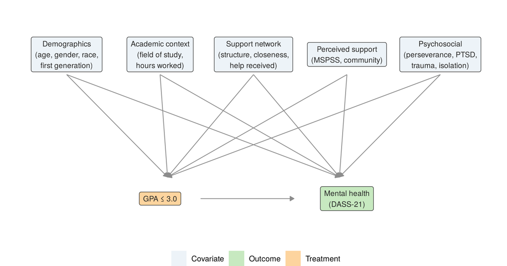

```r
nodes <- data.frame(
  name = c("Demographics\n(age, gender, race,\nfirst generation)",
           "Academic context\n(field of study,\nhours worked)",
           "Support network\n(structure, closeness,\nhelp received)",
           "Perceived support\n(MSPSS, community)",
           "Psychosocial\n(perseverance, PTSD,\ntrauma, isolation)",
           "GPA ≤ 3.0", "Mental health\n(DASS-21)"),
  x = c(1, 2.5, 4, 5.5, 7, 2.5, 5.5),
  y = c(3, 3, 3, 3, 3, 1, 1),
  type = c(rep("Covariate", 5), "Treatment", "Outcome"))
edges <- rbind(
  data.frame(x = nodes$x[1:5], y = 2.72, xend = 2.62, yend = 1.3),
  data.frame(x = nodes$x[1:5], y = 2.72, xend = 5.38, yend = 1.3),
  data.frame(x = 3.15, y = 1, xend = 4.65, yend = 1))
ggplot() +
  geom_segment(data = edges, aes(x, y, xend = xend, yend = yend),
               arrow = arrow(length = unit(0.18, "cm"), type = "closed"),
               colour = "grey55", linewidth = 0.4) +
  geom_label(data = nodes, aes(x, y, label = name, fill = type), key_glyph = "rect",
             size = 3, label.padding = unit(0.3, "lines"), colour = "grey15") +
  scale_fill_manual(values = c(Covariate = "#EDF3F8", Treatment = "#FDD49E", Outcome = "#C7E9C0"),
                    name = NULL) +
  coord_cartesian(xlim = c(0.3, 7.7), ylim = c(0.5, 3.6)) +
  theme_void(base_size = 11) + theme(legend.position = "bottom")
```

For each treatment, the propensity score model uses **all measured variables except** the outcome, the self-reported effect of COVID-19 on mental health (`covid_mh`, a proxy for the outcome), and the variable the treatment is built from. Because all variables were measured in the same survey, some covariates may act as mediators for some treatments, and the estimates should be read as effects under the stated assumptions.

## 4. Propensity scores and weights

Propensity scores $\hat p_i = \Pr(D_i = 1 \mid \mathbf{x}_i)$ are estimated with XGBoost, separately within each analytic sample. The settings are deliberately conservative for samples of this size.

| Setting | Value |
| --- | --- |
| Objective | binary:logistic (log loss) |
| Learning rate (eta) | 0.05 |
| Maximum tree depth | 2 |
| Minimum child weight | 5 |
| Row and column subsampling | 0.8 |
| Number of rounds | 5-fold cross-validation, early stopping after 25 rounds, maximum 1000 |
| Final model | Refit on the full analytic sample with the selected number of rounds |
| Missing values (age only) | Handled natively (learned default split direction) |

The core of the estimation in `R/causal_ipw.R`:

```r
# Propensity scores, in the original row order
dall <- xgboost::xgb.DMatrix(data.matrix(X), label = D, missing = NA)
cv   <- xgboost::xgb.cv(params = xgb_params, data = dall, nrounds = 1000,
                        nfold = 5, early_stopping_rounds = 25, verbose = 0)
best <- which.min(cv$evaluation_log$test_logloss_mean)
fit  <- xgboost::xgb.train(params = xgb_params, data = dall, nrounds = best)
p    <- predict(fit, dall)

# Unstabilized, untruncated ATE weights
w <- ifelse(D == 1, 1 / p, 1 / (1 - p))

# Weighted least squares of the outcome on the treatment, HC2 standard errors
est <- estimatr::lm_robust(mh_scale ~ D, weights = w, se_type = "HC2", alpha = 0.10)
```

Because the treatment is the only regressor, the coefficient on `D` equals the weighted difference in mean outcomes between the two groups, which is the IPW estimate of the ATE. “Robust” refers only to the HC2 sandwich standard errors. Stabilizing the weights would rescale them by a constant within each arm and leave the estimate unchanged.

## 5. Weighting diagnostics

### Balance, weights, and effective sample size (Supplementary Table S2)

Balance is measured by standardized mean differences (SMD), using the pooled standard deviation of the two groups *before* weighting as the denominator, so that the before and after columns are on the same scale. An absolute SMD below 0.1 indicates adequate balance.

```r
diag <- res %>%
  arrange(Group) %>%
  transmute(Group, Treatment,
            `Treated / control` = paste(n_treated, n_control, sep = " / "),
            `PS range` = sprintf("%.2f–%.2f", ps_min, ps_max),
            `Weight range` = sprintf("%.2f–%.2f", weight_min, weight_max),
            `ESS treated / control` = sprintf("%.0f / %.0f", ess_treated, ess_control),
            `Max |SMD| before` = round(max_abs_smd_before, 2),
            `Max |SMD| after`  = round(max_abs_smd_after, 2),
            `|SMD| > 0.1 before / after` = paste(n_smd_over_cutoff_before, n_smd_over_cutoff_after, sep = " / "))
kable(diag, caption = "Weighting diagnostics for all 46 analyses") %>%
  kable_styling(bootstrap_options = c("striped", "condensed"), font_size = 12) %>%
  collapse_rows(columns = 1, valign = "top") %>%
  scroll_box(height = "520px")
```

Weighting diagnostics for all 46 analyses

| Group | Treatment | Treated / control | PS range | Weight range | ESS treated / control | Max &#124;SMD&#124; before | Max &#124;SMD&#124; after | &#124;SMD&#124; > 0.1 before / after |
| --- | --- | --- | --- | --- | --- | --- | --- | --- |
| Full sample | GPA ≤ 3.0 | 69 / 226 | 0.16–0.34 | 1.20–5.39 | 68 / 226 | 0.22 | 0.18 | 20 / 15 |
|  | PTSD score ≥ 33 | 89 / 206 | 0.05–0.81 | 1.05–11.00 | 62 / 194 | 0.98 | 0.55 | 32 / 36 |
|  | COVID-19 isolation > 7 | 137 / 158 | 0.23–0.73 | 1.30–3.45 | 132 / 154 | 0.46 | 0.29 | 28 / 21 |
|  | Educational helpers ≥ 3 | 109 / 186 | 0.02–0.96 | 1.02–12.65 | 68 / 165 | 1.89 | 1.29 | 38 / 34 |
| High PTSD symptom severity | GPA ≤ 3.0 | 18 / 71 | 0.16–0.25 | 1.19–5.49 | 18 / 71 | 0.54 | 0.53 | 38 / 34 |
|  | COVID-19 isolation > 7 | 49 / 40 | 0.35–0.75 | 1.34–3.16 | 47 / 39 | 0.52 | 0.36 | 34 / 34 |
|  | Academic perseverance > median | 40 / 49 | 0.20–0.72 | 1.26–3.57 | 38 / 46 | 0.61 | 0.52 | 34 / 31 |
|  | Not a cisgender woman | 21 / 68 | 0.11–0.41 | 1.13–4.82 | 20 / 68 | 0.62 | 0.47 | 33 / 33 |
|  | Trauma score > median | 17 / 72 | 0.07–0.46 | 1.07–6.76 | 15 / 71 | 0.78 | 0.78 | 37 / 37 |
| Low PTSD symptom severity | GPA ≤ 3.0 | 51 / 155 | 0.24–0.25 | 1.31–4.20 | 51 / 155 | 0.39 | 0.38 | 24 / 24 |
|  | COVID-19 isolation > 7 | 88 / 118 | 0.28–0.57 | 1.39–3.21 | 86 / 116 | 0.53 | 0.39 | 33 / 28 |
|  | Academic perseverance > median | 100 / 106 | 0.20–0.84 | 1.20–3.28 | 94 / 102 | 0.55 | 0.38 | 31 / 26 |
|  | Not a cisgender woman | 47 / 159 | 0.20–0.27 | 1.24–4.87 | 47 / 159 | 0.37 | 0.35 | 27 / 25 |
|  | Trauma score > median | 101 / 105 | 0.17–0.80 | 1.20–3.30 | 95 / 100 | 0.53 | 0.35 | 28 / 26 |
| Cisgender women | GPA ≤ 3.0 | 53 / 174 | 0.21–0.27 | 1.26–4.80 | 53 / 174 | 0.33 | 0.29 | 21 / 21 |
|  | PTSD score ≥ 33 | 68 / 159 | 0.03–0.86 | 1.04–7.78 | 53 / 147 | 1.17 | 0.68 | 38 / 41 |
|  | COVID-19 isolation > 7 | 102 / 125 | 0.18–0.76 | 1.22–3.40 | 97 / 121 | 0.48 | 0.30 | 31 / 23 |
|  | Educational helpers ≥ 3 | 83 / 144 | 0.02–0.96 | 1.02–12.28 | 49 / 125 | 1.89 | 1.28 | 40 / 34 |
| Cisgender men | GPA ≤ 3.0 | 11 / 43 | 0.21–0.21 | 1.26–4.78 | 11 / 43 | 0.51 | 0.51 | 38 / 38 |
|  | PTSD score ≥ 33 | 15 / 39 | 0.27–0.27 | 1.38–3.66 | 15 / 39 | 0.91 | 0.91 | 40 / 40 |
|  | COVID-19 isolation > 7 | 30 / 24 | 0.40–0.71 | 1.41–2.55 | 29 / 24 | 0.80 | 0.72 | 32 / 31 |
|  | Educational helpers ≥ 3 | 21 / 33 | 0.21–0.59 | 1.27–3.48 | 20 / 32 | 2.13 | 1.91 | 44 / 45 |
| White students | GPA ≤ 3.0 | 20 / 107 | 0.11–0.21 | 1.13–7.05 | 20 / 107 | 0.45 | 0.46 | 33 / 31 |
|  | PTSD score ≥ 33 | 29 / 98 | 0.04–0.68 | 1.04–6.95 | 24 / 94 | 1.00 | 0.59 | 32 / 31 |
|  | COVID-19 isolation > 7 | 62 / 65 | 0.48–0.50 | 1.93–2.08 | 62 / 65 | 0.47 | 0.47 | 33 / 33 |
|  | Educational helpers ≥ 3 | 45 / 82 | 0.02–0.94 | 1.02–7.69 | 29 / 72 | 2.11 | 1.61 | 36 / 38 |
| Asian/Asian-American students | GPA ≤ 3.0 | 9 / 45 | 0.16–0.16 | 1.20–6.10 | 9 / 45 | 0.67 | 0.67 | 35 / 35 |
|  | PTSD score ≥ 33 | 18 / 36 | 0.28–0.38 | 1.38–3.45 | 18 / 36 | 1.39 | 1.28 | 43 / 42 |
|  | COVID-19 isolation > 7 | 23 / 31 | 0.42–0.43 | 1.72–2.39 | 23 / 31 | 0.71 | 0.71 | 31 / 31 |
|  | Educational helpers ≥ 3 | 21 / 33 | 0.29–0.54 | 1.40–2.85 | 21 / 33 | 2.09 | 1.93 | 40 / 40 |
| Students of other racial identities | GPA ≤ 3.0 | 40 / 74 | 0.33–0.38 | 1.49–3.00 | 40 / 74 | 0.49 | 0.47 | 34 / 34 |
|  | PTSD score ≥ 33 | 42 / 72 | 0.02–0.90 | 1.02–9.68 | 25 / 67 | 0.98 | 0.57 | 33 / 32 |
|  | COVID-19 isolation > 7 | 52 / 62 | 0.31–0.60 | 1.45–2.88 | 50 / 60 | 0.59 | 0.38 | 31 / 30 |
|  | Educational helpers ≥ 3 | 43 / 71 | 0.02–0.95 | 1.02–9.25 | 28 / 45 | 1.66 | 1.16 | 41 / 38 |
| Ages 18–20 | GPA ≤ 3.0 | 14 / 70 | 0.17–0.17 | 1.20–5.97 | 14 / 70 | 0.50 | 0.50 | 35 / 35 |
|  | PTSD score ≥ 33 | 31 / 53 | 0.06–0.82 | 1.07–4.76 | 27 / 49 | 1.23 | 0.85 | 42 / 41 |
|  | COVID-19 isolation > 7 | 41 / 43 | 0.30–0.69 | 1.44–2.99 | 39 / 41 | 0.68 | 0.49 | 32 / 31 |
|  | Max. emotional help ≥ 9 | 62 / 22 | 0.28–0.95 | 1.05–2.27 | 61 / 21 | 1.87 | 1.76 | 48 / 45 |
| Ages 21–24 | GPA ≤ 3.0 | 31 / 61 | 0.33–0.34 | 1.49–3.05 | 31 / 61 | 0.49 | 0.49 | 34 / 34 |
|  | PTSD score ≥ 33 | 31 / 61 | 0.08–0.73 | 1.09–8.71 | 21 / 57 | 1.11 | 0.73 | 35 / 42 |
|  | COVID-19 isolation > 7 | 47 / 45 | 0.38–0.63 | 1.58–2.60 | 46 / 44 | 0.52 | 0.52 | 33 / 31 |
|  | Max. emotional help ≥ 9 | 65 / 27 | 0.24–0.93 | 1.07–3.15 | 59 / 27 | 1.63 | 1.55 | 38 / 35 |
| Ages 25+ | GPA ≤ 3.0 | 8 / 31 | 0.21–0.21 | 1.27–4.70 | 8 / 31 | 1.42 | 1.42 | 41 / 41 |
|  | PTSD score ≥ 33 | 6 / 33 | 0.15–0.15 | 1.18–6.50 | 6 / 33 | 1.30 | 1.30 | 51 / 51 |
|  | COVID-19 isolation > 7 | 13 / 26 | 0.34–0.34 | 1.51–2.96 | 13 / 26 | 1.08 | 1.08 | 41 / 41 |
|  | Max. emotional help ≥ 9 | 34 / 5 | 0.87–0.87 | 1.15–7.80 | 34 / 5 | 2.37 | 2.37 | 46 / 46 |

Across all analyses, the weights range from **1.02 to 12.65**, and no propensity score is below 0.017 or above 0.958, so there are no extreme weights. Weighting reduces imbalance, but some covariates retain absolute SMDs above 0.1 in every analysis, which the paper acknowledges as a limitation.

### Covariate balance in the full sample

The plot shows, for each full-sample treatment, the 12 covariates with the largest imbalance before weighting (all SMDs are in `output/balance.csv`, provided as S1 Data).

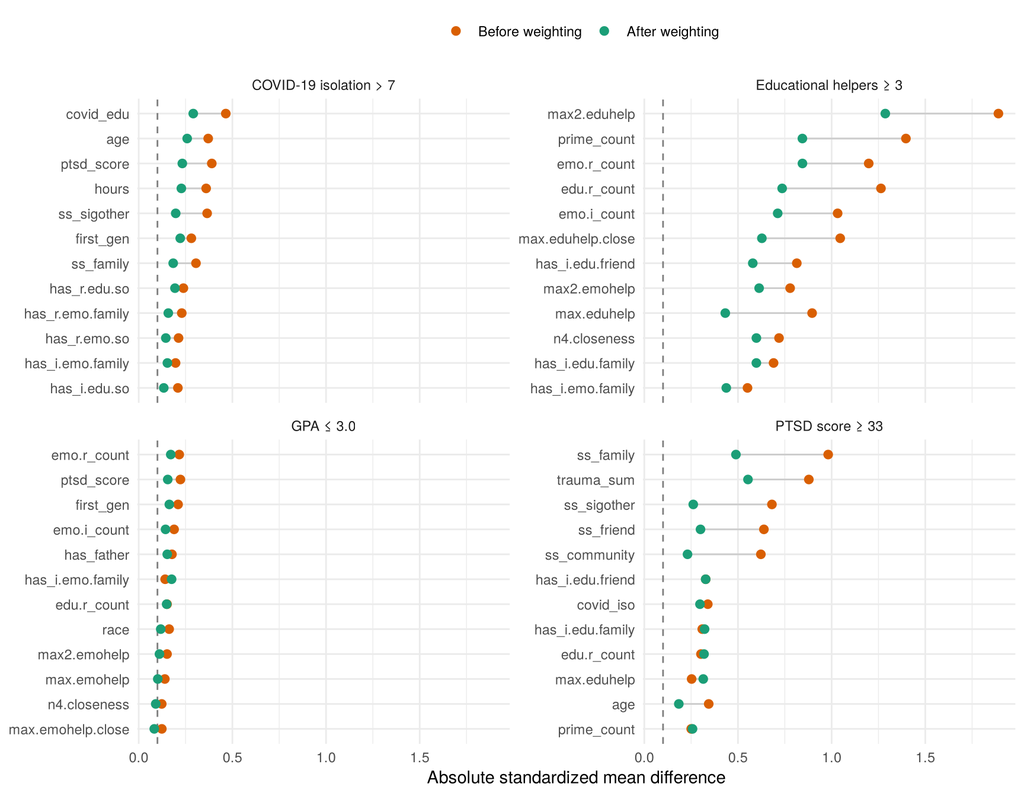

```r
full_bal <- bal %>%
  filter(group == "Full sample") %>%
  mutate(Treatment = unname(trt_labels[treatment])) %>%
  group_by(Treatment) %>%
  slice_max(abs(smd_before), n = 12) %>%
  ungroup() %>%
  pivot_longer(c(smd_before, smd_after), names_to = "when", values_to = "smd") %>%
  mutate(when = factor(when, c("smd_before", "smd_after"), c("Before weighting", "After weighting")),
         covariate = reorder(paste(covariate, Treatment, sep = "___"), abs(smd)))
ggplot(full_bal, aes(abs(smd), covariate, colour = when)) +
  geom_vline(xintercept = 0.1, linetype = "dashed", colour = "grey50") +
  geom_line(aes(group = covariate), colour = "grey80") +
  geom_point(size = 2.2) +
  scale_y_discrete(labels = function(x) sub("___.*$", "", x)) +
  scale_colour_manual(values = c("#D95F02", "#1B9E77"), name = NULL) +
  facet_wrap(~ Treatment, scales = "free_y") +
  labs(x = "Absolute standardized mean difference", y = NULL) +
  theme_minimal(base_size = 11) + theme(legend.position = "top")
```

### Overlap of propensity scores (Supplementary Fig S1)

Each panel shows the distribution of propensity scores among treated students (dark, upward) and comparison students (light, downward). Overlap is good for most treatments and more limited for PTSD symptom severity and educational help.

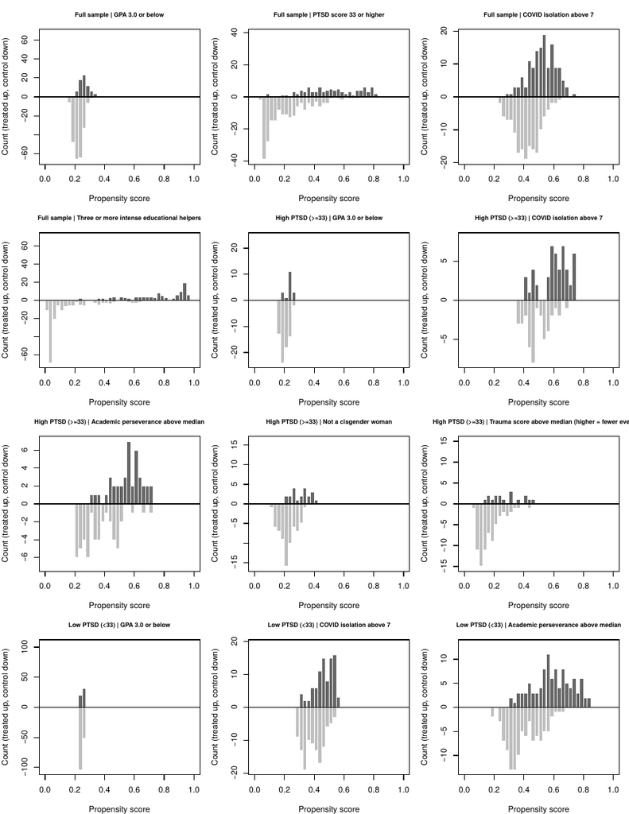

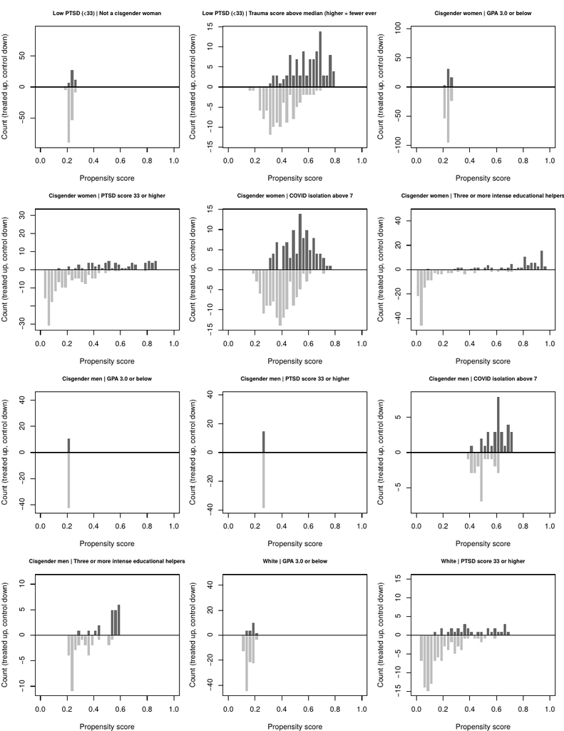

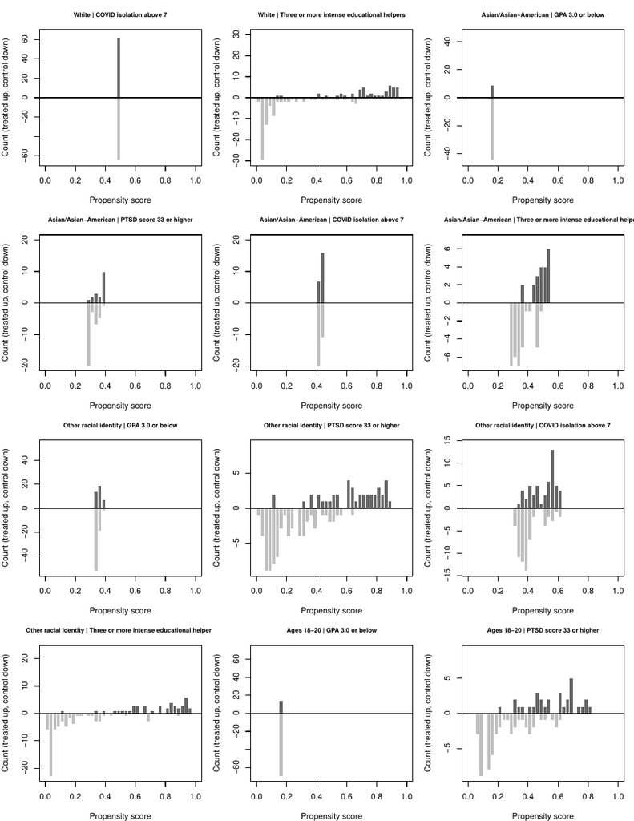

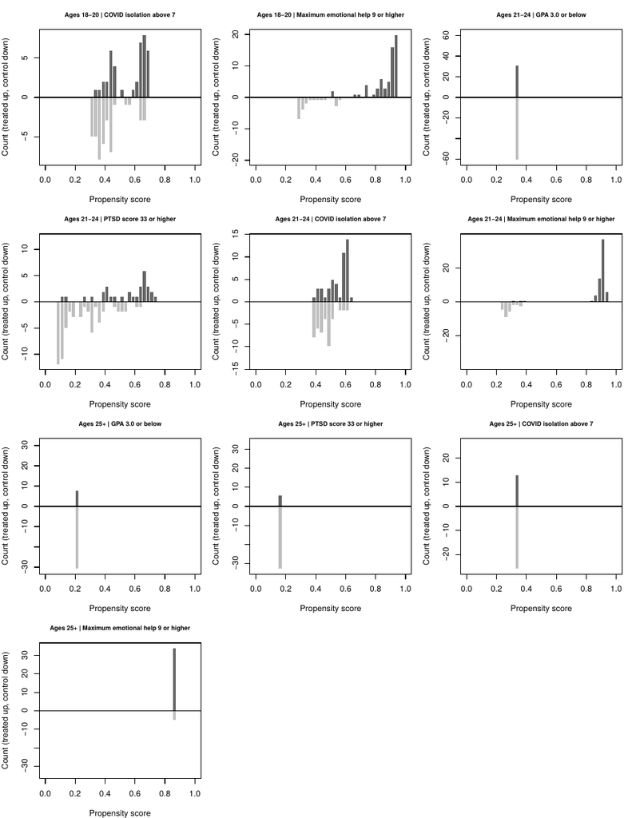

### A note on the smallest subgroups

In several small subgroups, cross-validation selected a model whose propensity scores barely vary. In those analyses the weights are nearly constant within each arm, so the weighted estimate is essentially the unadjusted difference in means. They are listed below for transparency.

```r
res %>%
  filter(ps_max - ps_min < 0.02) %>%
  transmute(Group, Treatment, n, `Treated / control` = paste(n_treated, n_control, sep = " / "),
            `PS range` = sprintf("%.3f–%.3f", ps_min, ps_max),
            `Weighted estimate` = round(estimate, 4),
            `Unadjusted difference` = round(raw_difference, 4)) %>%
  kable(caption = "Analyses with nearly constant propensity scores") %>%
  kable_styling(bootstrap_options = c("striped", "condensed"), font_size = 12)
```

Analyses with nearly constant propensity scores

| Group | Treatment | n | Treated / control | PS range | Weighted estimate | Unadjusted difference |
| --- | --- | --- | --- | --- | --- | --- |
| Low PTSD symptom severity | GPA ≤ 3.0 | 206 | 51 / 155 | 0.238–0.254 | -0.0300 | -0.0336 |
| Cisgender men | GPA ≤ 3.0 | 54 | 11 / 43 | 0.209–0.209 | 0.0777 | 0.0777 |
| Cisgender men | PTSD score ≥ 33 | 54 | 15 / 39 | 0.274–0.274 | 1.1790 | 1.1790 |
| White students | COVID-19 isolation > 7 | 127 | 62 / 65 | 0.482–0.499 | 0.1339 | 0.1367 |
| Asian/Asian-American students | GPA ≤ 3.0 | 54 | 9 / 45 | 0.164–0.164 | 0.0233 | 0.0233 |
| Asian/Asian-American students | COVID-19 isolation > 7 | 54 | 23 / 31 | 0.418–0.433 | 0.5484 | 0.5479 |
| Ages 18–20 | GPA ≤ 3.0 | 84 | 14 / 70 | 0.168–0.168 | -0.1034 | -0.1034 |
| Ages 21–24 | GPA ≤ 3.0 | 92 | 31 / 61 | 0.328–0.345 | -0.3783 | -0.3788 |
| Ages 25+ | GPA ≤ 3.0 | 39 | 8 / 31 | 0.213–0.213 | 0.3266 | 0.3266 |
| Ages 25+ | PTSD score ≥ 33 | 39 | 6 / 33 | 0.154–0.154 | 0.7828 | 0.7828 |
| Ages 25+ | COVID-19 isolation > 7 | 39 | 13 / 26 | 0.338–0.338 | 0.4945 | 0.4945 |
| Ages 25+ | Max. emotional help ≥ 9 | 39 | 34 / 5 | 0.872–0.872 | -0.2445 | -0.2445 |

## 6. Treatment effect estimates (Tables 3 to 7)

Estimates are in units of the Mental Health Scale (0 to 3). A positive estimate means the treated group has *more* distress, and a negative estimate means *less* distress. The tables report unadjusted p-values, Benjamini and Hochberg (BH) adjusted p-values, and 90% confidence intervals. Rows significant after adjustment are in **bold**; rows significant only before adjustment are in *italics*.

```r
make_table <- function(groups, caption) {
  d <- res %>% filter(Group %in% groups) %>% arrange(Group)
  out <- d %>% transmute(Group, Treatment,
                         Estimate = sprintf("%.4f", estimate),
                         `P-value` = fmt_p(p_value),
                         `BH p-value` = fmt_p(p_value_BH),
                         `90% CI` = sprintf("(%.4f, %.4f)", ci_lower, ci_upper))
  k <- kable(out %>% select(-Group), caption = caption, align = "lrrrr") %>%
    kable_styling(full_width = FALSE, bootstrap_options = c("condensed", "hover"))
  bold <- which(d$p_value_BH < alpha); ital <- which(d$p_value < alpha & d$p_value_BH >= alpha)
  if (length(bold)) k <- row_spec(k, bold, bold = TRUE)
  if (length(ital)) k <- row_spec(k, ital, italic = TRUE)
  for (g in unique(as.character(d$Group))) {
    idx <- which(as.character(d$Group) == g)
    if (length(groups) > 1) k <- pack_rows(k, g, min(idx), max(idx))
  }
  print(k)
}
make_table("Full sample", "Table 3. Full sample")
```

Table 3. Full sample

| Treatment | Estimate | P-value | BH p-value | 90% CI |
| --- | --- | --- | --- | --- |
| GPA ≤ 3.0 | -0.1014 | 0.2138 | 0.3270 | (-0.2358, 0.0329) |
| PTSD score ≥ 33 | 0.8197 | < 0.0001 | < 0.0001 | (0.7010, 0.9383) |
| COVID-19 isolation > 7 | 0.1461 | 0.0360 | 0.0920 | (0.0317, 0.2605) |
| Educational helpers ≥ 3 | -0.1889 | 0.0083 | 0.0346 | (-0.3061, -0.0717) |

```r
make_table(c("High PTSD symptom severity", "Low PTSD symptom severity"), "Table 4. Stratified by PTSD symptom severity")
```

Table 4. Stratified by PTSD symptom severity

| Treatment | Estimate | P-value | BH p-value | 90% CI |
| --- | --- | --- | --- | --- |
| **High PTSD symptom severity** |  |  |  |  |
| GPA ≤ 3.0 | -0.2495 | 0.0489 | 0.1034 | (-0.4572, -0.0418) |
| COVID-19 isolation > 7 | 0.0003 | 0.9981 | 0.9981 | (-0.1961, 0.1967) |
| Academic perseverance > median | 0.0139 | 0.9106 | 0.9688 | (-0.1915, 0.2193) |
| Not a cisgender woman | 0.1379 | 0.2895 | 0.3805 | (-0.0773, 0.3531) |
| Trauma score > median | -0.1388 | 0.3779 | 0.4575 | (-0.3991, 0.1216) |
| **Low PTSD symptom severity** |  |  |  |  |
| GPA ≤ 3.0 | -0.0300 | 0.6864 | 0.7701 | (-0.1524, 0.0925) |
| COVID-19 isolation > 7 | 0.1416 | 0.0121 | 0.0414 | (0.0492, 0.2340) |
| Academic perseverance > median | -0.1007 | 0.0763 | 0.1404 | (-0.1940, -0.0073) |
| Not a cisgender woman | -0.0875 | 0.1534 | 0.2613 | (-0.1884, 0.0134) |
| Trauma score > median | -0.0649 | 0.2669 | 0.3720 | (-0.1613, 0.0314) |

```r
make_table(c("Cisgender women", "Cisgender men"), "Table 5. Stratified by gender identity")
```

Table 5. Stratified by gender identity

| Treatment | Estimate | P-value | BH p-value | 90% CI |
| --- | --- | --- | --- | --- |
| **Cisgender women** |  |  |  |  |
| GPA ≤ 3.0 | -0.1628 | 0.0728 | 0.1395 | (-0.3120, -0.0136) |
| PTSD score ≥ 33 | 0.8076 | < 0.0001 | < 0.0001 | (0.6892, 0.9260) |
| COVID-19 isolation > 7 | 0.1562 | 0.0494 | 0.1034 | (0.0256, 0.2868) |
| Educational helpers ≥ 3 | -0.1845 | 0.0240 | 0.0691 | (-0.3187, -0.0504) |
| **Cisgender men** |  |  |  |  |
| GPA ≤ 3.0 | 0.0777 | 0.7282 | 0.7975 | (-0.2948, 0.4502) |
| PTSD score ≥ 33 | 1.1790 | < 0.0001 | < 0.0001 | (0.9495, 1.4085) |
| COVID-19 isolation > 7 | -0.0030 | 0.9873 | 0.9981 | (-0.3176, 0.3116) |
| Educational helpers ≥ 3 | -0.3770 | 0.0260 | 0.0704 | (-0.6526, -0.1014) |

```r
make_table(c("White students", "Asian/Asian-American students", "Students of other racial identities"),
           "Table 6. Stratified by race")
```

Table 6. Stratified by race

| Treatment | Estimate | P-value | BH p-value | 90% CI |
| --- | --- | --- | --- | --- |
| **White students** |  |  |  |  |
| GPA ≤ 3.0 | -0.1121 | 0.3939 | 0.4645 | (-0.3293, 0.1050) |
| PTSD score ≥ 33 | 0.9856 | < 0.0001 | < 0.0001 | (0.8278, 1.1433) |
| COVID-19 isolation > 7 | 0.1339 | 0.1813 | 0.2978 | (-0.0312, 0.2991) |
| Educational helpers ≥ 3 | -0.1965 | 0.0395 | 0.0956 | (-0.3529, -0.0400) |
| **Asian/Asian-American students** |  |  |  |  |
| GPA ≤ 3.0 | 0.0233 | 0.9267 | 0.9688 | (-0.3984, 0.4450) |
| PTSD score ≥ 33 | 0.9306 | < 0.0001 | < 0.0001 | (0.7062, 1.1550) |
| COVID-19 isolation > 7 | 0.5484 | 0.0018 | 0.0092 | (0.2693, 0.8274) |
| Educational helpers ≥ 3 | -0.1716 | 0.3125 | 0.3934 | (-0.4534, 0.1102) |
| **Students of other racial identities** |  |  |  |  |
| GPA ≤ 3.0 | -0.2404 | 0.0459 | 0.1034 | (-0.4378, -0.0429) |
| PTSD score ≥ 33 | 0.6741 | < 0.0001 | < 0.0001 | (0.4565, 0.8917) |
| COVID-19 isolation > 7 | 0.1183 | 0.3164 | 0.3934 | (-0.0767, 0.3133) |
| Educational helpers ≥ 3 | -0.3061 | 0.0222 | 0.0680 | (-0.5250, -0.0872) |

```r
make_table(c("Ages 18–20", "Ages 21–24", "Ages 25+"), "Table 7. Stratified by age")
```

Table 7. Stratified by age

| Treatment | Estimate | P-value | BH p-value | 90% CI |
| --- | --- | --- | --- | --- |
| **Ages 18–20** |  |  |  |  |
| GPA ≤ 3.0 | -0.1034 | 0.5855 | 0.6733 | (-0.4176, 0.2108) |
| PTSD score ≥ 33 | 0.8987 | < 0.0001 | < 0.0001 | (0.7147, 1.0827) |
| COVID-19 isolation > 7 | 0.2295 | 0.1122 | 0.1984 | (-0.0083, 0.4672) |
| Max. emotional help ≥ 9 | -0.1835 | 0.2204 | 0.3270 | (-0.4306, 0.0637) |
| **Ages 21–24** |  |  |  |  |
| GPA ≤ 3.0 | -0.3783 | 0.0046 | 0.0209 | (-0.5943, -0.1622) |
| PTSD score ≥ 33 | 1.0077 | < 0.0001 | < 0.0001 | (0.8142, 1.2013) |
| COVID-19 isolation > 7 | 0.1532 | 0.2759 | 0.3733 | (-0.0791, 0.3854) |
| Max. emotional help ≥ 9 | 0.2278 | 0.0650 | 0.1301 | (0.0251, 0.4304) |
| **Ages 25+** |  |  |  |  |
| GPA ≤ 3.0 | 0.3266 | 0.1988 | 0.3153 | (-0.0945, 0.7477) |
| PTSD score ≥ 33 | 0.7828 | 0.0091 | 0.0350 | (0.3029, 1.2628) |
| COVID-19 isolation > 7 | 0.4945 | 0.0126 | 0.0414 | (0.1764, 0.8126) |
| Max. emotional help ≥ 9 | -0.2445 | 0.2537 | 0.3648 | (-0.6004, 0.1113) |

### All 46 estimates at a glance

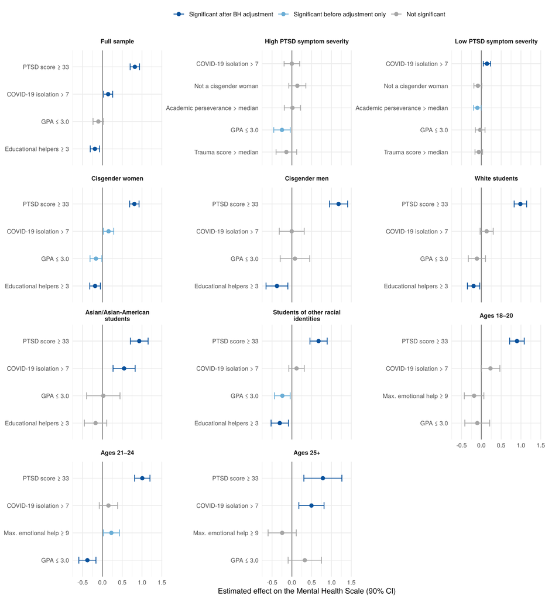

```r
res %>%
  mutate(sig = case_when(p_value_BH < alpha ~ "Significant after BH adjustment",
                         p_value < alpha    ~ "Significant before adjustment only",
                         TRUE               ~ "Not significant"),
         sig = factor(sig, c("Significant after BH adjustment",
                             "Significant before adjustment only", "Not significant"))) %>%
  ggplot(aes(estimate, reorder(Treatment, estimate), colour = sig)) +
  geom_vline(xintercept = 0, colour = "grey50") +
  geom_errorbarh(aes(xmin = ci_lower, xmax = ci_upper), height = 0.25) +
  geom_point(size = 2) +
  facet_wrap(~ Group, ncol = 3, scales = "free_y", labeller = label_wrap_gen(28)) +
  scale_colour_manual(values = c("#08519C", "#6BAED6", "grey65"), name = NULL) +
  labs(x = "Estimated effect on the Mental Health Scale (90% CI)", y = NULL) +
  theme_minimal(base_size = 10) +
  theme(legend.position = "top", strip.text = element_text(face = "bold"))
```

Two patterns stand out. PTSD symptom severity is associated with substantially greater distress in the full sample and in every gender, racial, and age subgroup in which it was examined, and having three or more educational helpers is associated with less distress in the full sample and most subgroups. The subgroup analyses are exploratory and the subgroups were not formally compared.

### Checks on the reported intervals

Every 90% confidence interval is symmetric about its estimate, with half-width equal to the 95th percentile of the $t$ distribution with $n - 2$ degrees of freedom times the HC2 standard error, as computed by `estimatr::lm_robust`.

```r
res %>%
  summarise(`Max |midpoint - estimate|` = max(abs((ci_lower + ci_upper) / 2 - estimate)),
            `Max |half-width - t x SE|` = max(abs((ci_upper - ci_lower) / 2 -
                                                qt(1 - alpha / 2, n - 2) * std_error))) %>%
  kable(digits = 8) %>% kable_styling(full_width = FALSE)
```

| Max &#124;midpoint - estimate&#124; | Max &#124;half-width - t x SE&#124; |
| --- | --- |
| 0 | 0 |

## 7. The Benjamini and Hochberg adjustment

The BH procedure controls the false discovery rate across all $m = 46$ estimates. With the unadjusted p-values sorted as $p_{(1)} \le \dots \le p_{(m)}$, the adjusted value at rank $i$ is

$$\tilde p_{(i)} = \min_{j \ge i} \left\{
\frac{m}{j}\, p_{(j)} \right\},$$

capped at 1. The step below recomputes the adjustment from the unadjusted p-values and confirms that it matches the values in the tables.

```r
bh <- p.adjust(res$p_value, method = "BH")
all.equal(bh, res$p_value_BH)
```

```
## [1] TRUE
```

The table shows ranks 13 to 22, where the running minimum matters. At ranks 13, 20 and 21 the raw value $m\,p_{(i)}/i$ is larger than a value at a higher rank, so the adjusted p-value is pulled down to that later value. This is why several rows in Tables 4 to 6 share an adjusted p-value of 0.1034.

```r
m <- nrow(res)
res %>%
  arrange(p_value) %>%
  mutate(Rank = row_number(), `m p / rank` = p_value * m / Rank) %>%
  slice(13:22) %>%
  transmute(Rank, Group, Treatment, `P-value` = round(p_value, 4),
            `m p / rank` = round(`m p / rank`, 4), `BH p-value` = round(p_value_BH, 4)) %>%
  kable() %>%
  kable_styling(bootstrap_options = c("striped", "condensed"), font_size = 12)
```

| Rank | Group | Treatment | P-value | m p / rank | BH p-value |
| --- | --- | --- | --- | --- | --- |
| 13 | Low PTSD symptom severity | COVID-19 isolation > 7 | 0.0121 | 0.0428 | 0.0414 |
| 14 | Ages 25+ | COVID-19 isolation > 7 | 0.0126 | 0.0414 | 0.0414 |
| 15 | Students of other racial identities | Educational helpers ≥ 3 | 0.0222 | 0.0680 | 0.0680 |
| 16 | Cisgender women | Educational helpers ≥ 3 | 0.0240 | 0.0691 | 0.0691 |
| 17 | Cisgender men | Educational helpers ≥ 3 | 0.0260 | 0.0704 | 0.0704 |
| 18 | Full sample | COVID-19 isolation > 7 | 0.0360 | 0.0920 | 0.0920 |
| 19 | White students | Educational helpers ≥ 3 | 0.0395 | 0.0956 | 0.0956 |
| 20 | Students of other racial identities | GPA ≤ 3.0 | 0.0459 | 0.1055 | 0.1034 |
| 21 | High PTSD symptom severity | GPA ≤ 3.0 | 0.0489 | 0.1071 | 0.1034 |
| 22 | Cisgender women | COVID-19 isolation > 7 | 0.0494 | 0.1034 | 0.1034 |

For example, isolation in the full sample has an unadjusted p-value of 0.0360 at rank 18, so its adjusted p-value is $0.0360 \times 46 / 18 = 0.0920$, which remains below $\alpha = 0.10$.

## Session information

The models in `output/` were fitted with the following software (from `output/session_info.txt`).

```
R version 4.6.1 (2026-06-24 ucrt)
[1] estimatr_2.0.1 ggplot2_4.0.3  ggdag_0.2.13   dagitty_0.3-4
 [34] xgboost_3.2.1.1      lubridate_1.9.5      Rcpp_1.1.1-1.1
```

This vignette was rendered with R version 4.3.3 (2024-02-29).